# Happiness Levels and Alcohol Consumption - Shiny

31/07/2020

## **About the App**

This app uses the *Happiness and Alcohol Consumption* data set obtained from **Kaggle** to build a linear regression model for observing the average happiness score of individuals across 122 countries, as a function of consumption of different alcoholic beverages as well as the Human Development Index(HDI).

The plots created are not particularly useful for making predictions, but can be used for observing and understanding the trends in and the structure of the data set.

[Link to Application on Shiny Server](https://pranavi-shekhar.shinyapps.io/Happiness-and-Alcohol-Consumption/?_ga=2.97795935.1517098402.1596159125-239562103.1596159125)

## **Description of the Data**

- This data set aims to explore the happiness levels of individuals based off of their **per capita consumption of alcoholic beverages** , **Human Development Index(HDI)** and GDP.
- Happiness Score is measured on a **scale of 1-10** with 10 being the happiest. The data set shows the **average** happiness score indicated by the country’s residents.
- The HDI used is provided by the United Nations. Further, the region and hemisphere of each country has been specified. The unit for per capita consumption of beverages is **Liters**. Again, the country wise average is shown.
- More details regarding the data set can be found **[here](https://www.kaggle.com/marcospessotto/happiness-and-alcohol-consumption)**

## **View the Data**

```r
data = read.csv("alcohol.csv",header = TRUE)
head(data,5)
```

```
      Country         Region Hemisphere HappinessScore HDI GDP_PerCapita
1     Denmark Western Europe      north          7.526 928        53.579
2 Switzerland Western Europe      north          7.509 943        79.866
3     Iceland Western Europe      north          7.501 933        60.530
4      Norway Western Europe      north          7.498 951        70.890
5     Finland Western Europe      north          7.413 918        43.433
  Beer_PerCapita Spirit_PerCapita Wine_PerCapita
1            224               81            278
2            185              100            280
3            233               61             78
4            169               71            129
5            263              133             97
```

## **Screenshot of the App**

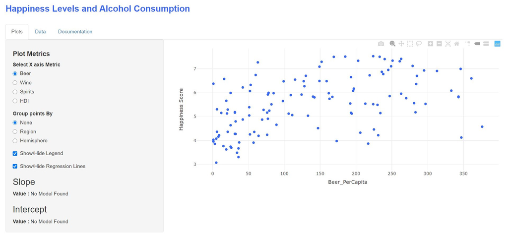